# Regression Concepts

## Regression Concepts

### Bivariate Regression

In this example, we will explore the question, does average monthly income depend on employees’ age? That is, we will explore the regresssion:

$$income_{i} = A + B \times age_{i} + E_{i}$$

In this example, I will simply demonstrate how we can obtain the coefficients for a simple bivariate regression using the sample statistics fro two variable age ($X$) and income ($Y$) that are in a dataset called “incex”. Here is a plot of $income \sim age$ with the OLS regression line:

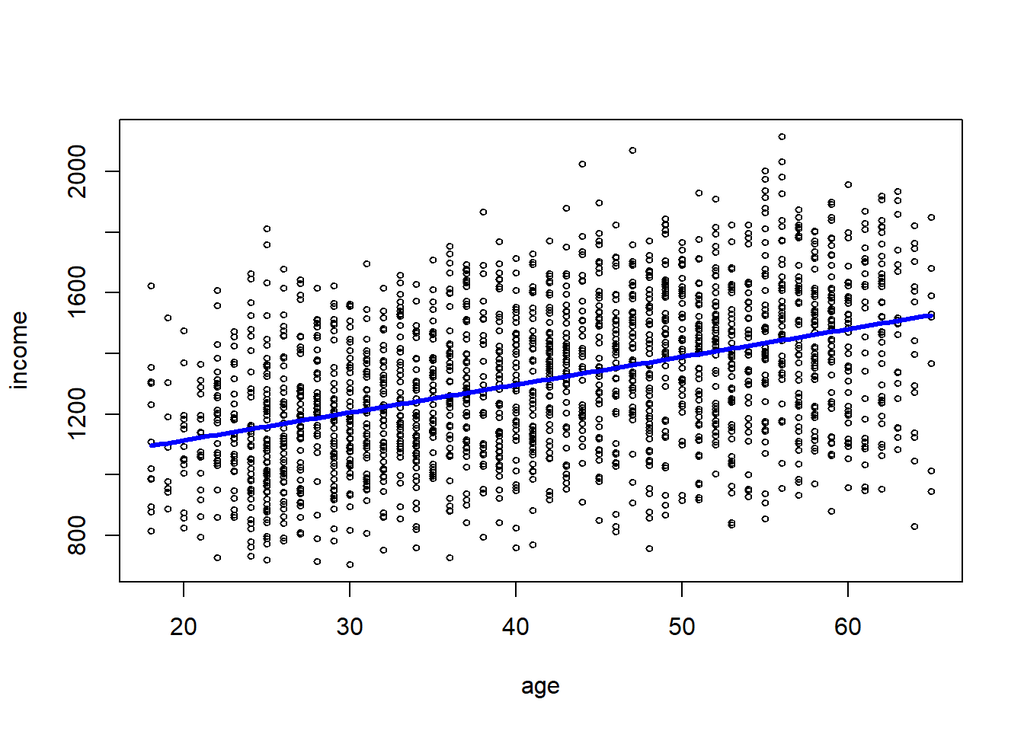

Here are the descriptive statistics for age ($X$) and income ($Y$):

```
##           mean std.dev      var    n
## age      41.69   12.22   149.42 1922
## income 1313.15  255.56 65312.13 1922
```

Here is the covariance matrix for age ($X$) and income ($Y$):

```
##            age   income
## age     149.42  1370.96
## income 1370.96 65312.13
```

Here is the correlation matrix for age ($X$) and income ($Y$):

```
##         age income
## age    1.00   0.44
## income 0.44   1.00
```

We could compute the correlation coefficient with the covariance of age and income and the standard deviations of age and income

$$r_{XY} = \frac{S_{XY}}{S_XS_Y} = \frac{1370.96}{12.22\times255.56}=0.44$$
We can compute the regression coefficeints by hand:

$$B = r_{XY}\times\frac{S_Y}{S_X}=0.439\times\frac{255.56}{12.22}=9.175$$
$$A = \bar{Y} - B \times \bar{X} = 1313.15 - 9.175 \times 41.69 = 930.64$$

We can verify our coefficients by fitting a linear regression model (I will use R here for ease of demonstration).

```
##
## Call:
## lm(formula = income ~ age, data = incex)
##
## Coefficients:
## (Intercept)          age
##     930.642        9.175
```

The results indicate that there is a positive linear relationship between age and income. An increase in age by one year increases the mean income by 9.2 dollars. An increase in age by 10 years increases the mean income by 92 dollars. Using the estimated regression equation:

$$income_{i} = 930.6 + 9.2 \times age_{i}$$
We can calculate the **conditional means for a given value of age**. These conditional means are also referred to as **predicted or fitted values**.

$$Age = 20: \hat{income}_{Age=20} = 930.6 + 9.2\times 20=1115$$
$$Age = 40: \hat{income}_{Age=40} = 930.6 + 9.2\times 40 = 1299$$
$$Age = 65: \hat{income}_{Age=65} = 930.6 + 9.2\times 65= 1529$$

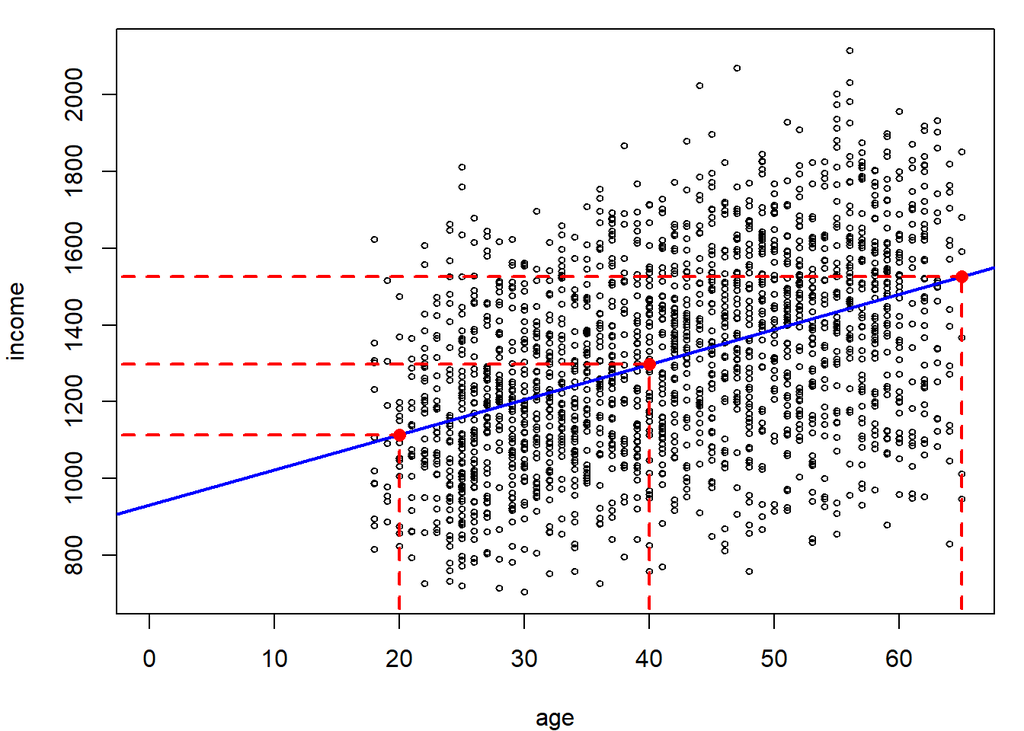

### Decomposition of Variance

Recall, the formula for the sums of squares

$$\sum^N_{i=1}(Y_{i}-\bar{Y})^2 = \sum^N_{i=1}(\hat{Y}_{i}-\bar{Y})^2 + \sum^N_{i=1}(Y_{i}-\hat{Y})^2$$

We can simply refer to these components as the TSS = Total sums of squares, RegSS = Regression sums of squares, and RSS = residual sums of squares.

$$TSS = RegSS + RSS$$

As an example, again using R for this simple demonstration, we can take the income on age linear model and extract the predicted values for each individual using the “predict” function in R. Then we can compute the TSS, RegSS, and show how this is related to the coefficient of determination.

```r
attach(incex)
out.lm <- lm(income ~ age, data = incex)
TSS <- sum((income - mean(income))^2)
RegSS <- sum((predict(out.lm) - mean(income))^2)
RSS <- sum((income - predict(out.lm))^2)
detach(incex)
c(TSS = TSS, RegSS = RegSS, RSS = RSS)
```

```
##       TSS     RegSS       RSS
## 125464601  24164128 101300473
```

Recall that the coefficient of determination is $R^2 = \frac{RegSS}{TSS}$ and that $R^2 = r^2_{XY}$

```r
# coef. of determination: R^2
RegSS / TSS
```

```
## [1] 0.1925972
```

```r
# correlation
sqrt(RegSS / TSS)
```

```
## [1] 0.4388589
```

```r
summary(out.lm)
```

```
##
## Call:
## lm(formula = income ~ age, data = incex)
##
## Residuals:
##     Min      1Q  Median      3Q     Max
## -687.86 -163.92    2.97  155.25  709.12
##
## Coefficients:
##             Estimate Std. Error t value Pr(>|t|)
## (Intercept) 930.6422    18.6254   49.97   <2e-16 ***
## age           9.1753     0.4287   21.40   <2e-16 ***
## ---
## Signif. codes:  0 '***' 0.001 '**' 0.01 '*' 0.05 '.' 0.1 ' ' 1
##
## Residual standard error: 229.7 on 1920 degrees of freedom
## Multiple R-squared:  0.1926, Adjusted R-squared:  0.1922
## F-statistic:   458 on 1 and 1920 DF,  p-value: < 2.2e-16
```

Note the multiple R-squared in the output.

### Partialling Out

In this example, we have three variables: math scores at pretest (mathpre or $Y_1$), math anxiety (mars or $X_2$), and vocabulary scores at pretest (vocabpre or $X_2$). In these examples, we are interested in predicting math scores at pretest using math axiety and vocabulary scores at pretest. The regression equation of interest is

$$mathpre_i = A + B_1 \times mars_i + B_2 \times vocabpre_i + E_{i}$$

Descriptive statistics on these variables are given here.

```
##     mathpre           mars           vocabpre
##  Min.   : 1.00   Min.   : 25.00   Min.   : 6
##  1st Qu.: 4.00   1st Qu.: 41.25   1st Qu.:18
##  Median : 6.00   Median : 53.56   Median :21
##  Mean   : 6.29   Mean   : 58.03   Mean   :21
##  3rd Qu.: 8.00   3rd Qu.: 74.00   3rd Qu.:25
##  Max.   :13.00   Max.   :125.00   Max.   :33
```

```r
# (i) regress mathpre on vocabpre
out.math <- lm(mathpre ~ vocabpre, data = scs)

# (ii) regress mars on vocabpre
out.mars <- lm(mars ~ vocabpre, data = scs)

# (iii)regress math residuals on mars residuals
summary(lm(out.math$residuals ~ out.mars$residuals))
```

```
##
## Call:
## lm(formula = out.math$residuals ~ out.mars$residuals)
##
## Residuals:
##     Min      1Q  Median      3Q     Max
## -5.1391 -1.9086 -0.0403  1.6498  5.7785
##
## Coefficients:
##                      Estimate Std. Error t value Pr(>|t|)
## (Intercept)        -1.463e-16  1.648e-01     0.0        1
## out.mars$residuals -3.211e-02  7.468e-03    -4.3 2.63e-05 ***
## ---
## Signif. codes:  0 '***' 0.001 '**' 0.01 '*' 0.05 '.' 0.1 ' ' 1
##
## Residual standard error: 2.388 on 208 degrees of freedom
## Multiple R-squared:  0.08163,    Adjusted R-squared:  0.07721
## F-statistic: 18.49 on 1 and 208 DF,  p-value: 2.628e-05
```

```r
# print coefficients only
round(coefficients(lm(out.math$residuals ~ out.mars$residuals)), 6)
```

```
##        (Intercept) out.mars$residuals
##           0.000000          -0.032109
```

To verify the results of the partialling out princple, let’s compare the coefficient for $B_1$ that we obtain with using these three regression models to the results we obtain with a simple linear model. Notice that the coefficient for **mars** is identitical to the one we computed using the partially out principle.

```r
coef(lm(mathpre ~ mars + vocabpre, data = scs))
```

```
## (Intercept)        mars    vocabpre
##  3.81845017 -0.03210865  0.20639070
```